# Assignment 3

Sophia Leiker

3/3/2023

## Adding Additional Car

Lets **scale** up from a single car to a group of cars on a highway and use our **autopower** function to estimate a distribution of power

4 car types

**Parameters**: Mean highway speed is 80 km/hr with a standard deviation of 10km/hr

```r
#sourcing our autopower function ("../R/autopower.R")
source(here("Working", "autopower.R"))


# generate a structure to store info on our possible cars
#Adding additional car: Car D with mass of 5000, and area of 10
possible_cars = data.frame(name = c("A","B","C", "D"),mass=c(10000,65000,38000,5000), area = c(22,30,22,10))

# first look at how results vary for mean speed say 100km/hr
# do conversion
speed_base = 80 * 0.28

# because I have one mass and area for each car and only 1 speed
# I can estimate power for each car type
# add to the data structure
possible_cars$power = autopower(V=speed_base, A = possible_cars$area, m=possible_cars$mass)

head(possible_cars)
```

```
##   name  mass area     power
## 1    A 10000   22  77436.12
## 2    B 65000   30 274724.89
## 3    C 38000   22 169634.52
## 4    D  5000   10  36694.96
```

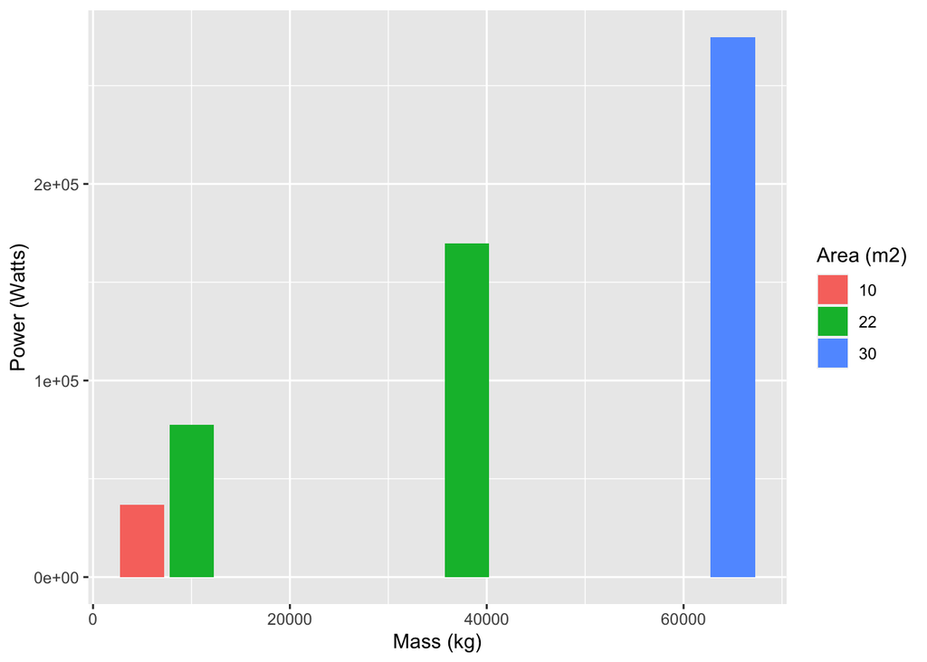

```r
# showing results here
ggplot(possible_cars, aes(x=mass, y=power, fill=as.factor(area)))+geom_col()+labs(y="Power (Watts)", x="Mass (kg)", fill="Area (m2)")
```

# Building a highway

How would the total power consumed vary by car So if all cars are car A; OR all cars are car B OR all cars are car C

- *pmap* for repetition - a efficient way of looping in R
- *for* for repetition - a more standard way of looping available in many langugaes

# Using `pmap`

```r
# assume a log normal distribution of speeds with mean 100km/hr
# recall our function needs speed in m/s not km/hr so we will also do a conversion
# lets get a sample of a 200 speeds- we could also do this by actually measuring speeds

nsample = 200
mean_speed = log(80*0.277)

#standard deviation that is 8% of the mean (b/c new SD is 10km/hr)
speeds = rlnorm(mean=mean_speed, sd=0.08*mean_speed, nsample)
summary(speeds)
```

```
##    Min. 1st Qu.  Median    Mean 3rd Qu.    Max.
##   10.95   18.75   22.37   23.01   26.78   44.93
```

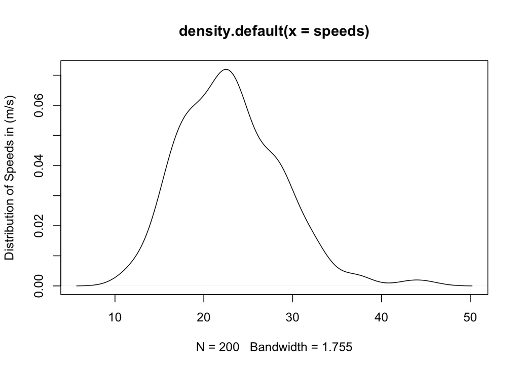

```r
plot(density(speeds), ylab="Distribution of Speeds in (m/s)")
```

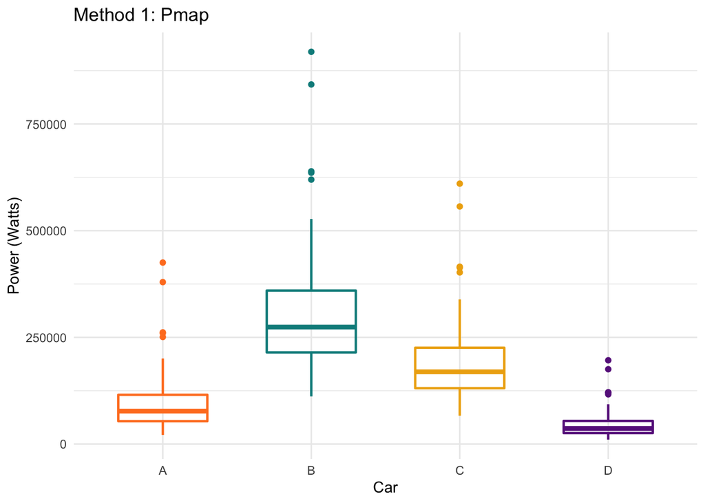

```r
# pmap runs a function for each value in a list of parameters, with other parameters set for each iteration
powerall2 = pmap(list(A = possible_cars$area, m=possible_cars$mass), autopower, V=speeds)

# lets turn to a data frame for easier graphing
# we can add column names
powerall2 = as.data.frame(powerall2, col.names=possible_cars$name)

# apply family of functions does this to - FYI
# what mapply does is run the function for each row in parameters listed, using values for other parameters listed in MoreArgs EACH time - a column for row in parameter list is returned
powerall2b = mapply(FUN=autopower, A = possible_cars$area, m=possible_cars$mass, MoreArgs = list(V=speeds)  )
# we can add column names
colnames(powerall2b)=possible_cars$name

#Can check the power for each of these options below by uncommenting
#head(powerall2b)
#head(powerall2)


# for plotting sometimes its useful to turn columns in to rows
powerallr2 = powerall2 %>% pivot_longer(cols=everything(), names_to="car", values_to="power")
#head(powerallr2)

#setting a color scheme to be consistent for each of the plots
color_scheme <- c("chocolate1", "cyan4", "darkgoldenrod2", "darkorchid4")

pmap_plot = ggplot(powerallr2, aes(car,power, fill=car))+
  scale_color_manual(values = color_scheme) +
  geom_boxplot(fill = NA, width = 0.6, lwd = 0.8, color = color_scheme)+
  ggtitle("Method 1: Pmap") +
    labs(x = "Car", y = "Power (Watts)") +
  theme_minimal()
pmap_plot
```

**Figure 1.** : Comparing results for the range of power consumption (across sampled speeds) uring pmap for each car type. Note that Car D is the superlight car

```r
# compare values by commenting out the below line
#head(powerallr2)

# not exactly the same - why?
# recall that we sample speeds!

# but we can compare means, map runs the function (here - mean), over each column, they are close but still not exact, so statistics such as means and quantiles are # similar, and relative difference between cars is the same
powerall2 %>% map(mean)
```

```
## $A
## [1] 91127.8
##
## $B
## [1] 297970.6
##
## $C
## [1] 185820.3
##
## $D
## [1] 42958.94
```

```r
# upper 90% quantile
powerall2 %>% map(quantile, probs=0.9)
```

```
## $A
##      90%
## 149068.1
##
## $B
##      90%
## 428570.2
##
## $C
##    90%
## 271884
##
## $D
##      90%
## 69751.97
```

# Using a `For Loop`

*pmap* works quickly but it is unique to R Other programming language (and R) use what are called loops - where repetition is more explicit

Lets do this one more time using a *for* loop

```r
# the first part, generating speeds is the same
# what is I want to estimate average power use given  each car

possible_cars
```

```
##   name  mass area     power
## 1    A 10000   22  77436.12
## 2    B 65000   30 274724.89
## 3    C 38000   22 169634.52
## 4    D  5000   10  36694.96
```

```r
# use sample to generate a distribution of speeds

# assume a log normal distribution of speeds with mean 100km/hr
# recall our function needs speed in m/s not km/hr so we will also do a conversion
# lets get a sample of a 200 speeds- we could also do this by actually measuring speeds

nsample = 200
mean_speed = log(80*0.277)

speeds = rlnorm(mean=mean_speed, sd=0.08*mean_speed, nsample)
summary(speeds)
```

```
##    Min. 1st Qu.  Median    Mean 3rd Qu.    Max.
##   10.35   20.00   23.31   23.53   27.15   42.89
```

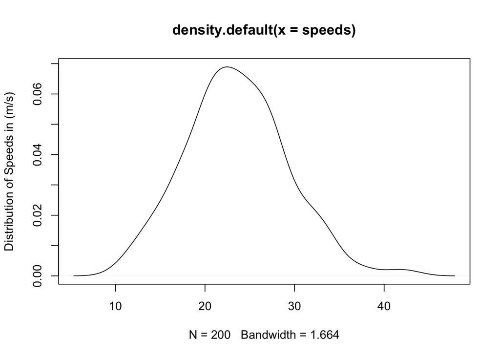

```r
plot(density(speeds), ylab="Distribution of Speeds in (m/s)")
```

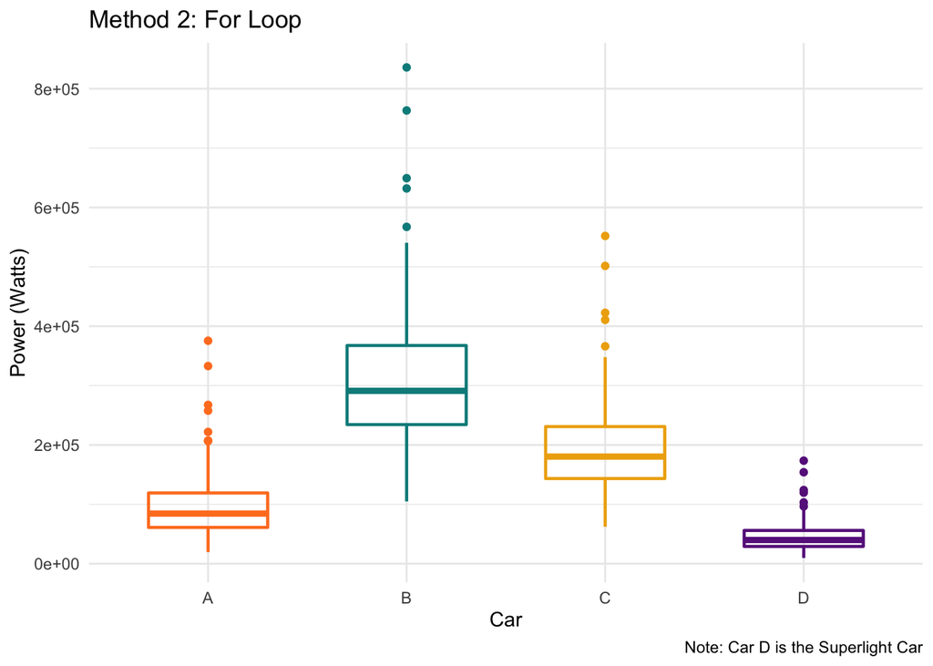

```r
# how do we run each car for all speeds, we use a for loop to cycle through, we need to create a data frame to store results - as above, one column for each car and one row for each speed

powerall3 = as.data.frame(matrix(nrow=length(speeds), ncol=nrow(possible_cars)))
# because we don't initialize it - values are NA
#head(powerall3)

# how many cars area there
#nrow(possible_cars)

# for loops use an index - in this case "i" but you could use anything - it repeats
# anything between the {} for each values of i between 1 and nrow(possible_car) (which is 3 in our case)

# index in to a matrix (like powerall3) is by row and column powerall3[2,5] is 2nd row and 5th column
for (i in 1:nrow(possible_cars)) {
  powerall3[,i] = autopower(A=possible_cars$area[i], m=possible_cars$mass[i], V=speeds)
}

# now it looks like above
#head(powerall3)
# we can add column names
colnames(powerall3)=possible_cars$name

# plotting is the same as above

# for plotting sometimes its useful to turn columns in to rows
powerallr3 = powerall3 %>% pivot_longer(cols=everything(), names_to="car", values_to="power")
#head(powerallr3)

# quick visualization
forloop_plot = ggplot(powerallr3, aes(car,power, fill=car))+
  scale_color_manual(values = color_scheme) +
  geom_boxplot(fill=NA, width = 0.6, lwd = 0.8, color = color_scheme) +
  ggtitle("Method 2: For Loop") +
  labs(x = "Car", y = "Power (Watts)", caption = "Note: Car D is the Superlight Car") +
  theme_minimal()+
  theme(legend.position = "none")

forloop_plot
```

**Figure 2.** : Comparing results for the range of power consumption (across sampled speeds) for each car type. Note that Car D is the superlight car

```r
powerall2 %>% map(mean)
```

```
## $A
## [1] 91127.8
##
## $B
## [1] 297970.6
##
## $C
## [1] 185820.3
##
## $D
## [1] 42958.94
```

```r
powerall3 %>% map(mean)
```

```
## $A
## [1] 95527.1
##
## $B
## [1] 307904.3
##
## $C
## [1] 192364.5
##
## $D
## [1] 44993.45
```

# Final Box Plots

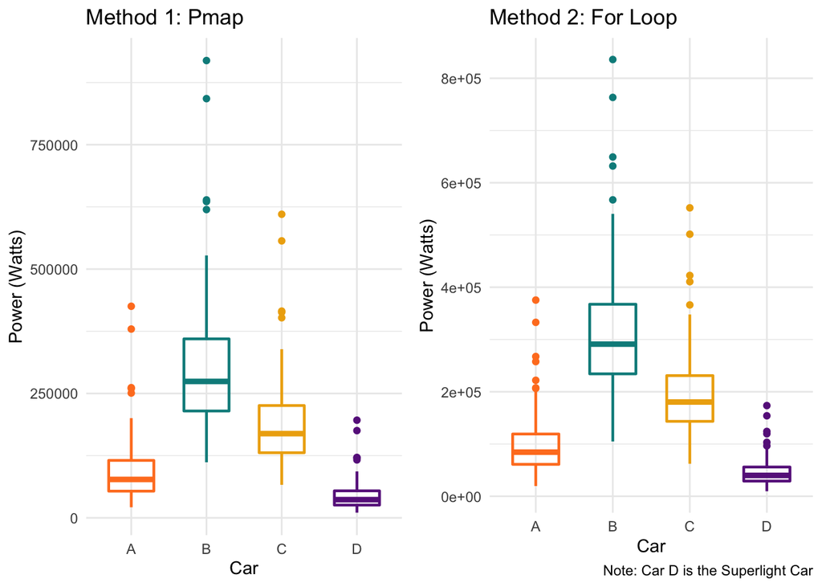

```r
#Making Final Boxplot here
ggarrange(pmap_plot, forloop_plot, ncol=2)
```

**Figure 3.** : Comparing results for the range of power consumption (across sampled speeds) for each car type. Note that Car D is the superlight car